```r
options(repr.plot.width=7, repr.plot.height=3)
```

# Problem Description

Yammer is a social network for communicating with coworkers. Individuals share documents, updates, and ideas by posting them in groups. Yammer is free to use indefinitely, but companies must pay license fees if they want access to administrative controls, including integration with user management systems like ActiveDirectory.

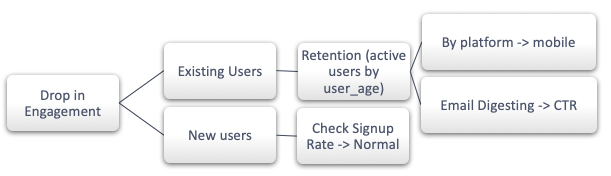

## A drop in Engagement

You show up to work Tuesday morning, September 2, 2014. The head of the Product team walks over to your desk and asks you what you think about the latest activity on the user engagement dashboards. You fire them up, and something immediately jumps out:

```r
suppressMessages({
library(ggplot2)
library(scales)
library(dplyr)
library(plotly)
library(sqldf)
})
```

```r
tutorial.yammer_events <- read.csv("/Users/lolofter/Documents/Rcode/tutorial.yammer_events.csv")
head(tutorial.yammer_events)
```

| user_id | occurred_at | event_type | event_name | location | device | user_type |
| --- | --- | --- | --- | --- | --- | --- |
| 10522 | 2014-05-02 11:02:39 | engagement | login | Japan | dell inspiron notebook | 3 |
| 10522 | 2014-05-02 11:02:53 | engagement | home_page | Japan | dell inspiron notebook | 3 |
| 10522 | 2014-05-02 11:03:28 | engagement | like_message | Japan | dell inspiron notebook | 3 |
| 10522 | 2014-05-02 11:04:09 | engagement | view_inbox | Japan | dell inspiron notebook | 3 |
| 10522 | 2014-05-02 11:03:16 | engagement | search_run | Japan | dell inspiron notebook | 3 |
| 10522 | 2014-05-02 11:03:43 | engagement | search_run | Japan | dell inspiron notebook | 3 |

```r
tutorial.yammer_users <- read.csv("/Users/lolofter/Documents/Rcode/tutorial.yammer_users.csv")
head(tutorial.yammer_users)
```

| user_id | created_at | company_id | language | activated_at | state |
| --- | --- | --- | --- | --- | --- |
| 0 | 2013-01-01 20:59:39 | 5737 | english | 2013-01-01 21:01:07 | active |
| 1 | 2013-01-01 13:07:46 | 28 | english |  | pending |
| 2 | 2013-01-01 10:59:05 | 51 | english |  | pending |
| 3 | 2013-01-01 18:40:36 | 2800 | german | 2013-01-01 18:42:02 | active |
| 4 | 2013-01-01 14:37:51 | 5110 | indian | 2013-01-01 14:39:05 | active |
| 5 | 2013-01-01 13:39:51 | 2463 | spanish |  | pending |

```r
tutorial.yammer_events$occurred_at = as.Date(tutorial.yammer_events$occurred_at)
```

```r
drop_week <- tutorial.yammer_events %>%
             filter(event_type == "engagement") %>%
             group_by(date_trunc=cut(occurred_at,"week")) %>%
             summarise(weekly_active_users=n_distinct(user_id))
```

```r
drop_week$date_trunc = as.POSIXct(drop_week$date_trunc)
```

```r
p<-ggplot(data=drop_week,aes(x=date_trunc,y=weekly_active_users))+geom_line()+geom_point()+
  scale_x_datetime(date_breaks = "14 day", labels = date_format("%b %d"))
#as_widget(ggplotly(p))
p
```

[figure not shown]

###### How do your define engagement?

Define engagement as having made some type of server call by interacting with the product. The number of users who logged at least one engagement event during the week starting date.

- Visit homepage
- Like message
- Login
- Search Autocomplete
- Search click result 1 - 10
- Search Run
- Send Message
- View inbox

###### Sign up

- Create user
- Enter email
- Enter info
- Complete Signup

```r
tutorial.yammer_events %>% group_by(event_type,event_name) %>% summarise(count=n())
```

| event_type | event_name | count |
| --- | --- | --- |
| engagement | home_page | 94065 |
| engagement | like_message | 59248 |
| engagement | login | 38610 |
| engagement | search_autocomplete | 17820 |
| engagement | search_click_result_1 | 1413 |
| engagement | search_click_result_10 | 506 |
| engagement | search_click_result_2 | 1499 |
| engagement | search_click_result_3 | 1134 |
| engagement | search_click_result_4 | 1264 |
| engagement | search_click_result_5 | 968 |
| engagement | search_click_result_6 | 805 |
| engagement | search_click_result_7 | 709 |
| engagement | search_click_result_8 | 690 |
| engagement | search_click_result_9 | 784 |
| engagement | search_run | 13019 |
| engagement | send_message | 33105 |
| engagement | view_inbox | 55936 |
| signup_flow | complete_signup | 3680 |
| signup_flow | create_user | 7298 |
| signup_flow | enter_email | 4407 |
| signup_flow | enter_info | 3872 |

## Possible Causes

1. Holiday (By country: If one country has much lower engagement than others, it’s possible that this is the cause.)
2. Broken feature (By device: If a mobile app was unstable and crashed, engagement would be down for only that device type. Or if something in the signup flow broke, preventing new users from joining Yammer, growth would also be down.)
3. Broken tracking code (Absolutely zero events of a certain type)
4. Traffic anomalies from bots. Through patterns or specific events.
5. Traffic shutdown to your site. Internet service provider blocked your site.
6. Marketing event. Super bowl. Ask the marketing team
7. Bad Data
8. Search crawler changes.

## Solving the Case

###### New users v.s Existing users?

1. **Growth Checking (Signup)**: One of the easiest things to check is growth, both because it’s easy to measure and because most companies (Yammer included) track this closely already. In this case, you have to make it yourself, though. You’ll notice that nothing has really changed about the growth rate—it continues to be high during the week, low on weekends:

```r
tutorial.yammer_users$created_at = as.POSIXct(as.Date(tutorial.yammer_users$created_at))
tutorial.yammer_users$activated_at = as.POSIXct(as.Date(tutorial.yammer_users$activated_at))
```

```r
growth = tutorial.yammer_users %>%
         filter(is.na(activated_at)&created_at>='2014-06-01'&created_at<'2014-09-01') %>%
         group_by(date=as.Date(created_at)) %>%
         summarise(total=n_distinct(user_id))
growth$type = "active"
all = tutorial.yammer_users %>%
      filter(created_at>='2014-06-01'&created_at<'2014-09-01') %>%
      group_by(date=as.Date(created_at)) %>%
      summarise(total=n_distinct(user_id))
all$type = "all"
comp = rbind(growth,all)
```

```r
# nothing has really changed about the growth rate—it continues to be high during the week, low on weekends:
p<-ggplot(data=comp, aes(x=date,y=total,color=type))+ geom_line()
p
#as_widget(ggplotly(p))
```

[figure not shown]

###### Retention problem ?

1. One of the most effective ways to look at this is to cohort users based on when they signed up for the product. This chart shows a decrease in engagement among users who signed up more than 10 weeks prior:

```r
full <- left_join(tutorial.yammer_events,tutorial.yammer_users)
```

```r
head(full)
```

| user_id | occurred_at | event_type | event_name | location | device | user_type | created_at | company_id | language | activated_at | state |
| --- | --- | --- | --- | --- | --- | --- | --- | --- | --- | --- | --- |
| 10522 | 2014-05-02 | engagement | login | Japan | dell inspiron notebook | 3 | 2014-04-03 18:00:00 | 1147 | japanese | 2014-04-03 18:00:00 | active |
| 10522 | 2014-05-02 | engagement | home_page | Japan | dell inspiron notebook | 3 | 2014-04-03 18:00:00 | 1147 | japanese | 2014-04-03 18:00:00 | active |
| 10522 | 2014-05-02 | engagement | like_message | Japan | dell inspiron notebook | 3 | 2014-04-03 18:00:00 | 1147 | japanese | 2014-04-03 18:00:00 | active |
| 10522 | 2014-05-02 | engagement | view_inbox | Japan | dell inspiron notebook | 3 | 2014-04-03 18:00:00 | 1147 | japanese | 2014-04-03 18:00:00 | active |
| 10522 | 2014-05-02 | engagement | search_run | Japan | dell inspiron notebook | 3 | 2014-04-03 18:00:00 | 1147 | japanese | 2014-04-03 18:00:00 | active |
| 10522 | 2014-05-02 | engagement | search_run | Japan | dell inspiron notebook | 3 | 2014-04-03 18:00:00 | 1147 | japanese | 2014-04-03 18:00:00 | active |

```r
str(full)
```

```
'data.frame':	340832 obs. of  12 variables:
 $ user_id     : num  10522 10522 10522 10522 10522 ...
 $ occurred_at : Date, format: "2014-05-02" "2014-05-02" ...
 $ event_type  : Factor w/ 2 levels "engagement","signup_flow": 1 1 1 1 1 1 1 1 1 1 ...
 $ event_name  : Factor w/ 21 levels "complete_signup",..: 7 5 6 21 19 19 7 6 20 5 ...
 $ location    : Factor w/ 47 levels "Argentina","Australia",..: 23 23 23 23 23 23 27 27 27 27 ...
 $ device      : Factor w/ 26 levels "acer aspire desktop",..: 6 6 6 6 6 6 12 12 12 12 ...
 $ user_type   : num  3 3 3 3 3 3 1 1 1 1 ...
 $ created_at  : POSIXct, format: "2014-04-03 18:00:00" "2014-04-03 18:00:00" ...
 $ company_id  : num  1147 1147 1147 1147 1147 ...
 $ language    : Factor w/ 12 levels "arabic","chinese",..: 8 8 8 8 8 8 3 3 3 3 ...
 $ activated_at: POSIXct, format: "2014-04-03 18:00:00" "2014-04-03 18:00:00" ...
 $ state       : Factor w/ 2 levels "active","pending": 1 1 1 1 1 1 1 1 1 1 ...
```

```r
full$created_at = as.Date(full$created_at)
full$activated_at = as.Date(full$activated_at)
```

```r
full$age = round(difftime(as.Date("2014-09-01"),full$activated_at, unit="weeks"))
full$age = ifelse(full$age > 9, "10+",full$age)
```

```r
head(full)
```

| user_id | occurred_at | event_type | event_name | location | device | user_type | created_at | company_id | language | activated_at | state | age |
| --- | --- | --- | --- | --- | --- | --- | --- | --- | --- | --- | --- | --- |
| 10522 | 2014-05-02 | engagement | login | Japan | dell inspiron notebook | 3 | 2014-04-04 | 1147 | japanese | 2014-04-04 | active | 10+ |
| 10522 | 2014-05-02 | engagement | home_page | Japan | dell inspiron notebook | 3 | 2014-04-04 | 1147 | japanese | 2014-04-04 | active | 10+ |
| 10522 | 2014-05-02 | engagement | like_message | Japan | dell inspiron notebook | 3 | 2014-04-04 | 1147 | japanese | 2014-04-04 | active | 10+ |
| 10522 | 2014-05-02 | engagement | view_inbox | Japan | dell inspiron notebook | 3 | 2014-04-04 | 1147 | japanese | 2014-04-04 | active | 10+ |
| 10522 | 2014-05-02 | engagement | search_run | Japan | dell inspiron notebook | 3 | 2014-04-04 | 1147 | japanese | 2014-04-04 | active | 10+ |
| 10522 | 2014-05-02 | engagement | search_run | Japan | dell inspiron notebook | 3 | 2014-04-04 | 1147 | japanese | 2014-04-04 | active | 10+ |

```r
sum1 <- full %>%
        filter(event_type=="engagement") %>%
        group_by(date=cut(occurred_at,"week"),age) %>%
        summarize(count = n_distinct(user_id))
```

```r
p<-ggplot(sum1,aes(x=as.POSIXct(date),y=count,fill=age))+
   geom_col(position = position_dodge2(width = 0.9, preserve = "single"))+
   scale_x_datetime(date_breaks = "14 day", labels = date_format("%b %d"))
p
#as_widget(ggplotly(p))
```

[figure not shown]

###### Retention Problem by Platform?

the problem probably isn’t related to a one-time spike from marketing traffic or something that is affecting new traffic to the site like being blocked or changing rank on search engines.

```r
table(tutorial.yammer_events$device)
```

```
   acer aspire desktop   acer aspire notebook      amazon fire phone
                  5402                   9372                   2298
       asus chromebook  dell inspiron desktop dell inspiron notebook
                 10014                  10569                  20476
   hp pavilion desktop                htc one               ipad air
                  9280                   4485                   9994
             ipad mini              iphone 4s               iphone 5
                  5895                  10097                  27134
             iphone 5s            kindle fire        lenovo thinkpad
                 16705                   4280                  38679
              mac mini            macbook air            macbook pro
                  4622                  28104                  59948
              nexus 10                nexus 5                nexus 7
                  5446                  17249                   6895
       nokia lumia 635  samsumg galaxy tablet    samsung galaxy note
                  5880                   1920                   2821
     samsung galaxy s4        windows surface
                 19594                   3673
```

```r
tutorial.yammer_events$platform = ifelse(tutorial.yammer_events$device %in% c('macbook pro','lenovo thinkpad','macbook air','dell inspiron notebook',
          'asus chromebook','dell inspiron desktop','acer aspire notebook','hp pavilion desktop','acer aspire desktop','mac mini'), "computer",
                                        ifelse(tutorial.yammer_events$device %in% c('iphone 5','samsung galaxy s4','nexus 5','iphone 5s','iphone 4s','nokia lumia 635',
       'htc one','samsung galaxy note','amazon fire phone'), "phone", ifelse(tutorial.yammer_events$device %in% c('ipad air','nexus 7','ipad mini','nexus 10','kindle fire','windows surface',
        'samsumg galaxy tablet'), "tablet",NA)))
```

```r
by_device = tutorial.yammer_events %>%
            filter(event_type=="engagement") %>%
            group_by(date=cut(occurred_at,"week"),platform) %>%
            summarise(count=n_distinct(user_id))
head(by_device)
```

| date | platform | count |
| --- | --- | --- |
| 2014-04-28 | computer | 415 |
| 2014-04-28 | phone | 281 |
| 2014-04-28 | tablet | 111 |
| 2014-05-05 | computer | 712 |
| 2014-05-05 | phone | 461 |
| 2014-05-05 | tablet | 187 |

```r
by_date = tutorial.yammer_events %>%
            filter(event_type=="engagement") %>%
            group_by(date=cut(occurred_at,"week"),platform="any") %>%
            summarise(count=n_distinct(user_id))
head(by_date)
comp = rbind(by_device,by_date)
```

| date | platform | count |
| --- | --- | --- |
| 2014-04-28 | any | 701 |
| 2014-05-05 | any | 1054 |
| 2014-05-12 | any | 1094 |
| 2014-05-19 | any | 1147 |
| 2014-05-26 | any | 1113 |
| 2014-06-02 | any | 1173 |

```r
p <- ggplot(comp, aes(x=as.POSIXct(date),y=count,color=platform))+
    geom_line()
p
#as_widget(ggplotly(p))
```

[figure not shown]

There’s a pretty steep drop in phone engagement rates. So it’s likely that there’s a problem with the mobile app related to long-time user retention.

- ask around. anything changed recently with the mobile app?
- what causes people to engage with the product?
  - The purpose of the digest email mentioned above is to bring users back into the product. Since we know this problem relates to the retention of long-time users, it’s worth checking out whether the email has something to do with it.

###### What causes Retention Problems on Mobile app? Digest Email?

```r
tutorial.yammer_emails <- read.csv("/Users/lolofter/Documents/Rcode/tutorial.yammer_emails.csv")
```

```r
head(tutorial.yammer_emails)
```

| user_id | occurred_at | action | user_type |
| --- | --- | --- | --- |
| 0 | 2014-05-06 09:30:00 | sent_weekly_digest | 1 |
| 0 | 2014-05-13 09:30:00 | sent_weekly_digest | 1 |
| 0 | 2014-05-20 09:30:00 | sent_weekly_digest | 1 |
| 0 | 2014-05-27 09:30:00 | sent_weekly_digest | 1 |
| 0 | 2014-06-03 09:30:00 | sent_weekly_digest | 1 |
| 0 | 2014-06-03 09:30:25 | email_open | 1 |

```r
tutorial.yammer_emails$occurred_at = as.POSIXct(tutorial.yammer_emails$occurred_at)
```

```r
by_email <- tutorial.yammer_emails %>%
            filter(occurred_at>="2014-05-01" & occurred_at<"2014-09-01") %>%
            group_by(date=cut(as.Date(occurred_at),"week"),action) %>%
            summarise(count = n_distinct(user_id))
head(by_email)
```

| date | action | count |
| --- | --- | --- |
| 2014-04-28 | email_clickthrough | 185 |
| 2014-04-28 | email_open | 330 |
| 2014-04-28 | sent_reengagement_email | 96 |
| 2014-04-28 | sent_weekly_digest | 908 |
| 2014-05-05 | email_clickthrough | 425 |
| 2014-05-05 | email_open | 902 |

```r
p<- ggplot(by_email%>%filter(date!="2014-09-01"),aes(x=as.POSIXct(date),y=count,color=action)) +
    geom_line()
p
#as_widget(ggplotly(p))
```

[figure not shown]

Clickthroughs are way down.

digest emails in addition to mobile apps.

# References

- [Investigating a Drop in User Engagement](https://mode.com/sql-tutorial/a-drop-in-user-engagement/)